# Tarea Estadistica

## 5.3 - Análisis gráfico, histograma y boxplot

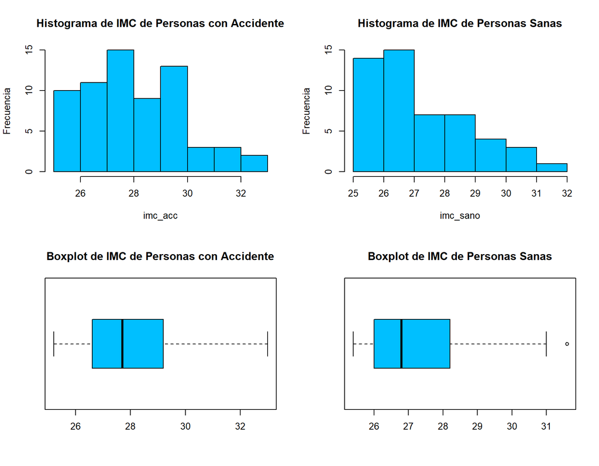

```r
par(mfrow=c(2,2)) #Para mostrar varios gráficos al tiempo
hist(imc_acc, col = "deepskyblue", main = "Histograma de IMC de Personas con Accidente", ylab = "Frecuencia")
hist(imc_sano, col = "deepskyblue", main = "Histograma de IMC de Personas Sanas", ylab = "Frecuencia")
boxplot(imc_acc, col = "deepskyblue",  main = "Boxplot de IMC de Personas con Accidente", horizontal = TRUE)
points(mean(imc_acc),pch=8)
boxplot(imc_sano, col = "deepskyblue", main = "Boxplot de IMC de Personas Sanas", horizontal= TRUE)
points(mean(imc_sano),pch=8)
```

En la siguiente salida vemos los valores numéricos de los cuartiles representados por nuestros gráficos boxplot.

```r
summary(imc_acc)
```

```
##    Min. 1st Qu.  Median    Mean 3rd Qu.    Max.
##   25.20   26.60   27.70   28.09   29.20   33.00
```

```r
summary(imc_sano)
```

```
##    Min. 1st Qu.  Median    Mean 3rd Qu.    Max.
##   25.40   26.00   26.80   27.35   28.20   31.60
```

Resultados: el análisis de los gráficos de histograma concuerda con lo planteado anteriormente. Se observa claramente la distribución bimodal para el grupo que sufrió un accidente y la distribución asimétrica de cola derecha para las personas sanas.

Cuando los datos son asimétricos, la mayoría de los datos se ubican en la parte superior o inferior de la gráfica. La asimetría indica que los datos pueden no estar distribuidos normalmente.Estas gráficas de caja ilustran los datos asimétricos.Tenemos un outlier en el grupo de personas sanas con un IMC más elevado que el resto.

En ambos casos la parte izquierda de la caja es menor que la de la derecha; ello quiere decir que las personas con IMC comprendidas entre el 25% y el 50% de la población está menos dispersa que entre el 50% y el 75%. El bigote de la izquierda (Xmím, Q 1 ) es más corto que el de la derecha; por ello el 25% de las personas con menor IMC están más concentrados que el 25% de las personas con IMC mayor.

# 6 - Estudiando la normalidad

En estadística hay una gran cantidad de modelos, pruebas y procedimientos que tienen como supuesto la normalidad, por lo tanto, se hace necesario contar con herramientas que nos guíen para responder si se cumple o no el supuesto de normalidad.

En el contraste de normalidad la hipótesis nula es la hipótesis de normalidad, esto es, no hay diferencias entre nuestra distribución y una distribución normal con esa media y esa desviación típica. Para contrastar la normalidad usamos el test de Shapiro-Wilk, con la función shapiro.test( ).

```r
shapiro.test(imc_acc)
```

```
##
##  Shapiro-Wilk normality test
##
## data:  imc_acc
## W = 0.95766, p-value = 0.02426
```

```r
shapiro.test(imc_sano)
```

```
##
##  Shapiro-Wilk normality test
##
## data:  imc_sano
## W = 0.90142, p-value = 0.0004692
```

De la salida anterior se observa que ambos valores-P fueron menores al nivel de significancia 5%, por lo tanto, se puede concluir que ambas muestras provienen de poblaciones con una distribución distinta a la normal.

# 7 - Intervalo de confianza

```r
t.test(x=imc_acc, y=imc_sano,
       paired=FALSE,
       conf.level = 0.95)$conf.int
```

```
## [1] 0.1188321 1.3649469
## attr(,"conf.level")
## [1] 0.95
```

A partir del intervalo de confianza anterior se puede concluir, con un nivel de confianza del 95 %, que el IMC promedio de las personas que han sufrido un accidente es superior al IMC promedio de aquellos que no lo han sufrido, ya que el intervalo de confianza NO incluye el cero y es positivo. En este caso el intervalo resultante de la diferencia de medias es (0,12-1,36).

# 8 - Contraste de Hipótesis

El contraste de hipotesis es una regla de decisión para elegir entre dos hipótesis: la nula y la alternativa.

## 8.1 - Contraste de diferencia de medias

Vamos a realizar el contraste de hipótesis siguiente:
$$\left\{
\begin{array}{ll}
H_{0}: & \mu_1=\mu_2\\
H_{0}: & \mu_1\neq\mu_2
\end{array}
\right.$$
Para realizar este procedimiento un supuesto importante además de la independencia de muestras es el suspuesto sobre la varianza cuando es desconocida. Hay dos casos cuando la varianza es desconocida en las dos muestras pero igual y cuando las varianzas son distintas.

Como aún no hemos contrastado la igualdad de varianzas entre las dos muestras calcularemos los dos contrastes en ambos supuestos. El código es

```r
sol.ttest.vareq=t.test(imc_acc,imc_sano,alternative="two.side",var.equal=TRUE,conf.level=0.95)
sol.ttest.vareq
```

```
##
##  Two Sample t-test
##
## data:  imc_acc and imc_sano
## t = 2.3205, df = 115, p-value = 0.02207
## alternative hypothesis: true difference in means is not equal to 0
## 95 percent confidence interval:
##  0.1086155 1.3751634
## sample estimates:
## mean of x mean of y
##  28.09091  27.34902
```

```r
sol.ttest.vareq$statistic
```

```
##        t
## 2.320544
```

```r
sol.ttest.vareq$p.value
```

```
## [1] 0.02207443
```

```r
sol.ttest.vareq$conf.int
```

```
## [1] 0.1086155 1.3751634
## attr(,"conf.level")
## [1] 0.95
```

```r
sol.ttest.varneq=t.test(imc_acc,imc_sano,alternative="two.side",var.equal=FALSE,conf.level=0.95)
sol.ttest.varneq
```

```
##
##  Welch Two Sample t-test
##
## data:  imc_acc and imc_sano
## t = 2.359, df = 113.01, p-value = 0.02004
## alternative hypothesis: true difference in means is not equal to 0
## 95 percent confidence interval:
##  0.1188321 1.3649469
## sample estimates:
## mean of x mean of y
##  28.09091  27.34902
```

```r
sol.ttest.varneq$statistic
```

```
##        t
## 2.359036
```

```r
sol.ttest.varneq$p.value
```

```
## [1] 0.02003907
```

```r
sol.ttest.varneq$conf.int
```

```
## [1] 0.1188321 1.3649469
## attr(,"conf.level")
## [1] 0.95
```

De la salida anterior se observa que ambos valores-P fueron menores al nivel de significancia 5%, por lo tanto, se puede concluir que ambas casos la diferencia de medias es distinta a cero (se rechaza la hipotesis nula), es decir, las medias no son iguales.

## 8.2 - Contraste de igualdad de varianzas

Del ejercicio anterior nos queda pendiente comprobar la igualdad de varianzas. En el contraste de homogeneidad de varianzas la hipótesis nula es la varianza es constante (no varía) en los diferentes grupos. Para contrastarla podemos utilizar el test F de Snedecor con var.test( ), que se aplica cuando solo hay dos grupos.

```r
sol.var.test=var.test(imc_acc, imc_sano,ratio=1,alternative="two.sided",conf.level=0.95)
sol.var.test
```

```
##
##  F test to compare two variances
##
## data:  imc_acc and imc_sano
## F = 1.2915, num df = 65, denom df = 50, p-value = 0.3476
## alternative hypothesis: true ratio of variances is not equal to 1
## 95 percent confidence interval:
##  0.7557265 2.1672196
## sample estimates:
## ratio of variances
##            1.29153
```

```r
sol.var.test$statistic
```

```
##       F
## 1.29153
```

```r
sol.var.test$p.value
```

```
## [1] 0.3475579
```

```r
sol.var.test$conf.int
```

```
## [1] 0.7557265 2.1672196
## attr(,"conf.level")
## [1] 0.95
```

El p-valor asociado al contraste es 0.3476. Como este valor es superior al nivel de significación (que para este ejemplo es 0.05), no podemos rechazar la hipótesis nula que hemos planteado. Es decir, se puede considerar que la varianza del grupo de personas que sufrió un accidente y la varianza del grupo de personas que no lo sufrió son iguales.

Cabe destacar que en este ejercicio comprobamos que las distribuciones no son normales para ninguna de las muestras. Esto nos indica que deberíamos plantearnos utilizar test estadísticos distintos para los contrastes de hipótesis ya que tanto el test-t como el var-test tienen como supuesto la normalidad. Se deja planteada la idea para posteriores investigaciones.

# 9 - Referencias bibliográficas

https://rpubs.com/daco92/579609 https://rstudio-pubs-static.s3.amazonaws.com/65042_a1784120e81a430f9de400ed9b899b0b.html#formulas-basicas-en-r-markdown-para-contrastes-de-hipotesis. https://wpd.ugr.es/~bioestad/guia-de-r/practica-6/ https://fhernanb.github.io/Manual-de-R/normalidad.html#consideraciones-iniciales https://rpubs.com/Jo_/contrastes_hipotesis_ttest